# Reproducible Research: Peer Assessment 1

This project project is to use R Markdown to allow any user to reproduce the current analysis workflow. The dataset *Activity monitoring data* will be used and the variables are the following:

- **steps**: Number of steps taking in a 5-minute interval
- **date**: The date in YYYY-MM-DD format
- **interval**: Identifier for the 5-minute interval

The first steps are to load the different libraries, to unzip the data file and load it in the data frame called **activity** in R.

```r
library(dplyr)
```

```r
library(ggplot2)
unzip(zipfile = "activity.zip")
activity <- read.csv("activity.csv", header = TRUE)
```

Here is a quick view of the data frame **activity**.

```r
head(activity)
```

```
##   steps       date interval
## 1    NA 2012-10-01        0
## 2    NA 2012-10-01        5
## 3    NA 2012-10-01       10
## 4    NA 2012-10-01       15
## 5    NA 2012-10-01       20
## 6    NA 2012-10-01       25
```

The data frame **activity** is composed as the following:

```r
str(activity)
```

```
## 'data.frame':    17568 obs. of  3 variables:
##  $ steps   : int  NA NA NA NA NA NA NA NA NA NA ...
##  $ date    : Factor w/ 61 levels "2012-10-01","2012-10-02",..: 1 1 1 1 1 1 1 1 1 1 ...
##  $ interval: int  0 5 10 15 20 25 30 35 40 45 ...
```

The column *date* is a factor and needs to be changed to the class “Date”.

```r
activity$date <- as.Date(as.character(activity$date, "%Y%m%d"))
```

The class of *date* has been succefully modified.

```r
str(activity)
```

```
## 'data.frame':    17568 obs. of  3 variables:
##  $ steps   : int  NA NA NA NA NA NA NA NA NA NA ...
##  $ date    : Date, format: "2012-10-01" "2012-10-01" ...
##  $ interval: int  0 5 10 15 20 25 30 35 40 45 ...
```

## What is mean total number of steps taken per day?

The number of cumulative steps per day is obtained the following line of code:

```r
steps_count <- activity %>% group_by(date) %>% summarize(total_steps = sum(steps, na.rm = TRUE))
```

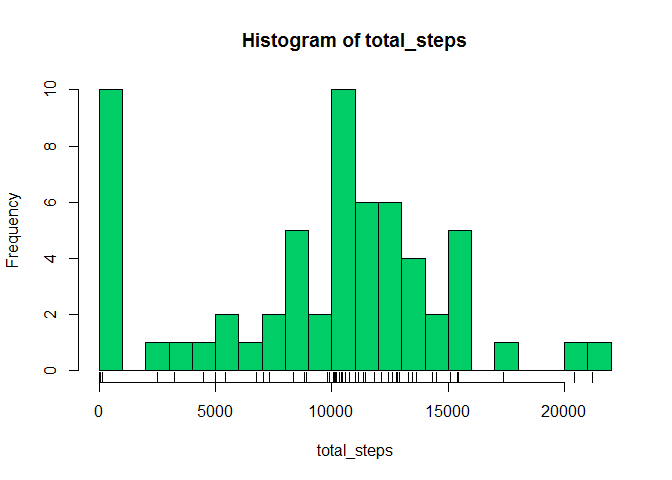

```r
with(steps_count, hist(total_steps, breaks = 30, col = "springgreen3"))
rug(steps_count$total_steps)
```

The *averaged number of steps* and *median number of steps* per day are given by

```r
steps_count_summary <- summary(steps_count$total_steps)
steps_count_summary
```

```
##    Min. 1st Qu.  Median    Mean 3rd Qu.    Max.
##       0    6778   10395    9354   12811   21194
```

The average number of steps per day is 9354 and the median is 10395.

## What is the average daily activity pattern?

To get the averaged number of steps per interval, run the following command:

```r
steps_mean_interval <- activity %>% group_by(interval) %>% summarize(mean_steps = mean(steps, na.rm = TRUE))
```

The plot of the time serie of the the averaged number of steps per 5-min interval is obtained using:

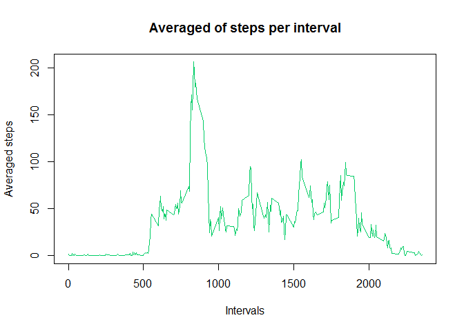

```r
with(steps_mean_interval, plot(x = interval, y = mean_steps, type = "l", col = "springgreen3", xlab = "Intervals", ylab = "Averaged steps"))
title("Averaged of steps per interval")
```

```r
max_mean_steps <- steps_mean_interval[which(steps_mean_interval$mean_steps == max(steps_mean_interval$mean_steps)), ]
max_mean_steps
```

```
## # A tibble: 1 x 2
##   interval mean_steps
##      <int>      <dbl>
## 1      835       206.
```

The maximum averaged number of time can be obtained by the code above and appears at the interval 835.

## Imputing missing values

Some intervals have missing values for the number of steps.

```r
missing_values <- 100 * mean(is.na(activity$steps))
```

The missing values corresponds to 13.1147541% of the dataset.

```r
steps_mean_int_temp <- rep(steps_mean_interval$mean_steps, each = length(unique(activity$date)))
```

```r
activity_new <- activity %>% arrange(date, interval)
idx <- which(is.na(activity_new$steps))
activity_new$steps[idx] = steps_mean_int_temp[idx]
str(activity_new)
```

```
## 'data.frame':    17568 obs. of  3 variables:
##  $ steps   : num  1.72 1.72 1.72 1.72 1.72 ...
##  $ date    : Date, format: "2012-10-01" "2012-10-01" ...
##  $ interval: int  0 5 10 15 20 25 30 35 40 45 ...
```

The values of the total number of steps and the histogram are updated, as well as the mean and the median.

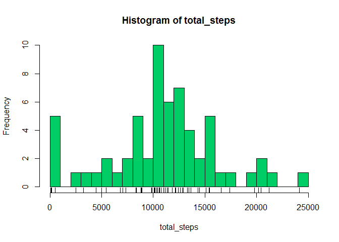

```r
steps_count <- activity_new %>% group_by(date) %>% summarize(total_steps = sum(steps, na.rm = TRUE))
with(steps_count, hist(total_steps, breaks = 30, col = "springgreen3"))
rug(steps_count$total_steps)
```

```r
steps_count_summary <- summary(steps_count$total_steps)
steps_count_summary
```

```
##    Min. 1st Qu.  Median    Mean 3rd Qu.    Max.
##      41    8821   11015   10890   13460   24150
```

The updated average number of steps per day is 10889 and the updated median value is 11015.

The updated mean and median are higher compared to the first analysis. By imputing the missing values, the data frame may get closer to the true values.

## Are there differences in activity patterns between weekdays and weekends?

Anew column days has been added to data frame **activity_new** which gives the days of the week when the steps have been recorded.

```r
activity_new <- activity_new %>% mutate(days = weekdays(date))
head(activity_new)
```

```
##      steps       date interval   days
## 1 1.716981 2012-10-01        0 Monday
## 2 1.716981 2012-10-01        5 Monday
## 3 1.716981 2012-10-01       10 Monday
## 4 1.716981 2012-10-01       15 Monday
## 5 1.716981 2012-10-01       20 Monday
## 6 1.716981 2012-10-01       25 Monday
```

A new data frame with the each day of the week is classified by weekday or weekend has been created and used to annotate the data frame **activity_new**.

```r
days <- unique(activity_new$days)
classifier <- rep(c("weekday", "weekend"), c(5,2))
week_identifier <- cbind(days,classifier)
activity_new <- merge(activity_new, week_identifier, by = "days", all.x = TRUE)
head(activity_new)
```

```
##     days steps       date interval classifier
## 1 Friday     0 2012-10-05     2220    weekday
## 2 Friday     0 2012-11-16      430    weekday
## 3 Friday     0 2012-10-05     2235    weekday
## 4 Friday     0 2012-11-16      435    weekday
## 5 Friday     0 2012-10-05     2315    weekday
## 6 Friday     0 2012-11-16      445    weekday
```

The mean accross the intervals should be recalculated according to the weekdays classifier.

```r
steps_mean_interval_new <- activity_new %>% group_by(interval, classifier) %>% summarize(mean_steps = mean(steps, na.rm = TRUE))
```

A plot of the mean for each interval in the weekdays and the weekend is generated using the following command lines.

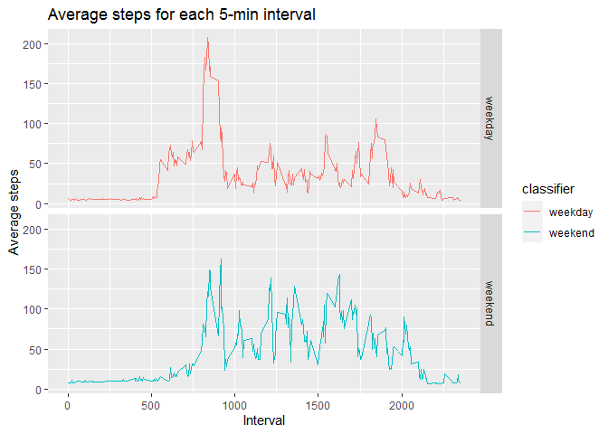

```r
g <- ggplot(steps_mean_interval_new, aes(interval, mean_steps))
g + geom_line(aes(color = classifier)) + facet_grid(classifier~.) + labs(x = "Interval", y = "Average steps", title = "Average steps for each 5-min interval")
```